```python
from IPython.display import display, Image
```

# Python for Measurement Automation

Training for RF engineers.

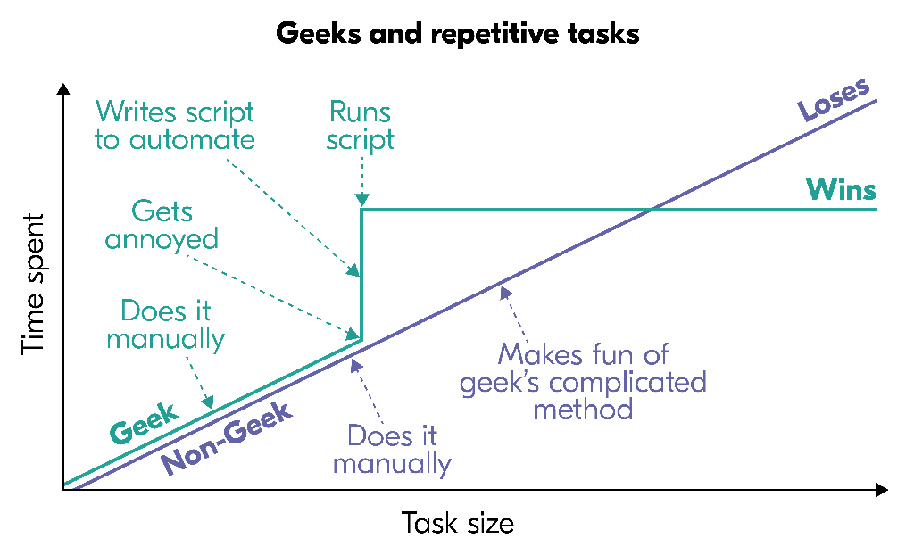

## Installation

Assuming Windows is used:

- [Python 3.9](https://www.python.org/downloads/windows/) - Aardvark does not support 3.10 yet
- [Visual Studio Code](https://code.visualstudio.com/#alt-downloads) - Has good python autocompletion/debugging tools
- [git](https://git-scm.com/download/win) - Required to install the packages from github
- gs_instrument - GomSpace instrument package for python
- [NI VISA drivers](https://www.ni.com/da-dk/support/downloads/drivers/download.ni-visa.html) - **Optional:** Drivers required to use USB instruments
- [NI 488.2 GPIB drivers](https://www.ni.com/da-dk/support/downloads/drivers/download.ni-488-2.html) - **Optional:** Drivers required to use GPIB instruments

Remember to update the system PATH variable with the paths to `python.exe` and `git.exe`:

- Search "Edit the system environment variables"
- "Environment Variables..."
- Under "System variables" find `PATH` and click "Edit..."
- Add the path to the directory containing `python.exe`
- Add the path to the directory containing `git.exe`

## Minimal installation

In case you did not get Git access, the following steps can be used to follow the class:

1. Install [Python 3.9](https://www.python.org/downloads/windows/)
2. Install [Visual Studio Code](https://code.visualstudio.com/#alt-downloads)
3. Make sure `python.exe` is found in the system PATH.
4. Install `gs_instrument` from a temporary file on the `V:`-drive (see below)

To install `gs_instrument`:

```
python -m pip install -U V:/gs_instrument.zip
```

## Exercise 0: Testing your setup

1. Install the tools
2. Write the program below
3. Run the program (`F5` or `Run->Start Debugging`) and see the output

```
from math import log10
P_W = 2
P_dBm = 10*log10(1000 * P_W)
print(f"Power = {P_W} W = {P_dBm} dBm")
```

```
import gs_instrument
gen = gs_instrument.signal_generator.cw.RohdeSchwarzSMF100A("10.0.9.197")
print(gen.get_id())
```

## Baseband instruments

| Category | Instrument |
| --- | --- |
| **Climate chamber** | Voetsch VT4002 |
| **I2C adapter** | TotalPhase Aardvark |
| **Multimeter** | Fluke 287 |
|  | Keysight EDU34450A |
| **Oscilloscope (screenshot only)** | Rigol DS1104Z |
|  | Keysight MSOX3104T |
|  | Agilent DSO1012A |
| **Power supply** | Rigol DP832 |
|  | Aim-TTi QL564TP |
|  | Aim-TTi CPX400SP |
|  | Aim-TTi PL303QMDP |
|  | Rohde & Schwarz HMC8042 |
|  | Rohde & Schwarz HMC8043 |
|  | Rohde & Schwarz HMP2020 |
| **Thermometer** | Fluke 80TK (used together with a multimeter) |

## RF instruments

| Category | Instrument |
| --- | --- |
| **Network analyzer (screenshot only)** | Rohde & Schwarz ZNB8 |
|  | Rohde & Schwarz ZNB20 |
| **RF tester** | Rohde & Schwarz CMA180 |
| **Signal generator (CW)** | Rohde & Schwarz SMIQ03B |
|  | Rohde & Schwarz CMA180 (used as a signal generator) |
|  | Rohde & Schwarz SMF100A |
|  | Rohde & Schwarz SMU200A |
|  | Rigol DSA832E (tracking generator used as signal generator) |
|  | Windfreak SynthHD PRO |
| **Signal generator (GFSK, BPSK, and QPSK)** | Rohde & Schwarz SMIQ03B |
|  | Rohde & Schwarz SMU200A |
| **Signal generator (ARB)** | Rohde & Schwarz SMU200A |
| **Spectrum analyzer** | Rohde & Schwarz FSU |
|  | Keysight CXA |
|  | Tektronix RSA306B |
|  | Rigol DSA832E |

## Utilities

| Utility | Description |
| --- | --- |
| CSV writer | Continuously write measurement data to disk |
| WV waveform generator | Generate arbitrary waveforms for Rohde & Schwarz generators |

## Code examples - get started quick, fast, in a hurry

All categories above have a code example, making it easy to get started.

### Example: Power supply example

1. Go to https://github.com/GomSpace/gs_instrument
2. Navigate to `examples/power_supply_example.py`
3. Copy the code and modify it to fit your needs.

## Where do I find instrument documentation?

The `gs_instrument` source code is documented. The easiest way to get help with the instrument API is to navigate the source code directly.

Visual Studio Code will also help with autocompletion and documentation.

### Example: Keysight CXA spectrum analyzer API

1. Go to https://github.com/GomSpace/gs_instrument
2. Navigate to `gs_instrument/spectrum_analyzer.py`
3. In the top of the file, find all the documented functions labeled with `@abstractmethod`
4. Find instrument specific setup by scrolling down to `KeysightCXA`

## LAN? Serial? GPIB? USB?

Some instruments have multiple interface, e.g. USB, LAN, or GPIB.

One interface is selected by default but it can also be changed.

Note that USB and GPIB generally require [NI VISA](https://www.ni.com/da-dk/support/downloads/drivers/download.ni-visa.html#409839) to be installed.

### Example: Change power supply interface to USB

Default setup is LAN:

```
psu = gs_instrument.power_supply.RohdeSchwarzHMC8043("10.0.8.147")
```

Here, the interface is changed to USB via NI VISA:

```
psu_phy = gs_instrument.InstrumentVISA(visa_address="USB0::0x0AAD::0x0135::030123385::INSTR")
psu = gs_instrument.power_supply.RohdeSchwarzHMC8043(phy=psu_phy)
```

Available interfaces: `InstrumentVXI11`, `InstrumentSocketASCII`, `InstrumentVISA`, `InstrumentSerial`.

## My favorite instrument is missing

Not all instruments in the lab are implemented in `gs_instrument` yet. In this case, you can create a minimal instrument and use SCPI commands from the datasheet directly.

### Example: Keysight 53230A frequency counter

```
import gs_instrument
inst = gs_instrument.InstrumentVXI11("10.0.8.116")

inst.write("INITIATE:IMMEDIATE")
inst.wait_for_operation_complete()
f = float(inst.query("FETCH?"))
print(f)
```

## My favorite function is missing

Not all functions from all instruments are implemented. Below are two examples for adding custom SCPI commands to an instrument:

### Directly using SCPI commands (simpler)

```
psu = gs_instrument.power_supply.RohdeSchwarzHMC8043("10.0.8.147")
psu.phy.write("OUTPUT:MASTER ON")
```

### Extending the instrument class (more elegant)

```
class RohdeSchwarzHMC8043Extended(gs_instrument.power_supply.RohdeSchwarzHMC8043):
    def set_master_enable(self):
        self.phy.write("OUTPUT:MASTER ON")

psu = RohdeSchwarzHMC8043Extended("10.0.8.147")
psu.set_master_enable()
```

# Let's build something

## Example 1: Power supply and multimeter

1. Sweep power supply voltage
2. Measure current with the power supply
3. Measure voltage with a multimeter

```
import time
import gs_instrument

psu = gs_instrument.power_supply.RohdeSchwarzHMC8043("10.0.8.147")
ch1 = gs_instrument.power_supply.Channel(psu, channel=1)

dmm = gs_instrument.multimeter.Fluke287("COM8")
output = gs_instrument.CsvWriter("example1.csv")

for V_in in [0, 1, 2, 3, 4, 5, 6, 7, 8, 9, 10]:
    ch1.set_voltage_V(V_in)
    ch1.set_output_enable()
    time.sleep(1)

    I_in = ch1.measure_current_A()
    V_out = dmm.measure_voltage_dc_V()
    record = {
        "Input voltage [V]": V_in,
        "Input current [A]": I_in,
        "Output voltage [V]": V_out,
    }
    print(record)
    output.write(record)

ch1.set_output_disable()
psu.close()
dmm.close()
```

## Example 2: Signal generator and spectrum analyzer

**Scalar network analyzer** with a CW generator and a spectrum analyzer.

This example should be easy to adapt for many common TX measurement such as:

- Frequency response (power vs. frequency)
- Compression point (output power vs. input power)
- Harmonics/spurious emissions (fixed generator frequency, sweeping analyzer frequency)

```
import time
import gs_instrument

INPUT_POWER_dBm = -10

gen = gs_instrument.signal_generator.cw.RohdeSchwarzSMF100A("10.0.9.197")
ana = gs_instrument.spectrum_analyzer.KeysightCXA("10.0.9.212")
output = gs_instrument.CsvWriter("example2.csv")

gen.set_cable_loss_dB(0.0)
gen.set_power_dBm(INPUT_POWER_dBm)
gen.set_output_enable()

ana.set_cable_loss_dB(0.0)
ana.set_reference_level_dBm(0)
ana.set_detector_positive_peak()
ana.set_frequency_span_Hz(1e6)
ana.set_bandwidth_resolution_Hz(100e3)
ana.set_bandwidth_video_Hz(100e3)
ana.set_sweep_time_s(0.1)
ana.set_sweep_points(1001)

for frequency_MHz in range(100, 2010, 10):
    frequency_Hz = frequency_MHz*1e6
    gen.set_frequency_Hz(frequency_Hz)

    ana.set_frequency_center_Hz(frequency_Hz)
    ana.set_trigger_single()
    ana.wait_for_operation_complete()

    ana.set_marker_max()
    P = ana.get_marker_y()
    record = {
        "Timestamp [s]": int(time.time()),
        "Frequency [Hz]": frequency_Hz,
        "Input power [dBm]": INPUT_POWER_dBm,
        "Output power [dBm]": P,
        "Gain [dB]": P - INPUT_POWER_dBm,
    }
    print(record)
    output.write(record)

gen.set_output_disable()
ana.close()
```

# Exercises

A signal generator and a spectrum analyzer have benn set up and connected to each other. They are both connected to LAN and you will be given their IP addresses.

## Exercise 1: Harmonics (1)

Based on the previous example, create a script that measures the harmonic emissions of a signal generator:

- Generator frequency: 500 MHz
- Generator power: 0 dBm
- Harmonics: 1, 2, 3, 4, 5
- Output columns: `Harmonic`, `Power [dBm]`

## Exercise 2: Harmonics (2)

Extend the script from Exercise 1 to include multiple frequencies and power levels:

- Generator frequencies: 100 MHz, 200 MHz, 500 MHz
- Generator power: -20 dBm, -10 dBm, 0 dBm
- Harmonics: 1, 2, 3, 4, 5
- Output columns: `Generator frequency [Hz]`, `Generator power [dBm]`, `Harmonic`, `Power [dBm]`

# Appendix: Data processing

The output data is in a CSV format which is easily processed in everything from R to Excel. Feel free to use whatever you feel most comfortable with.

Python also has very good libraries for data processing. Below are a few examples used for plotting the output from the examples and exercises.

A few libraries are required to use the examples. These are installed with the following command:

```
python -m pip install -U numpy matplotlib pandas seaborn
```

## Example 1: Power supply and multimeter

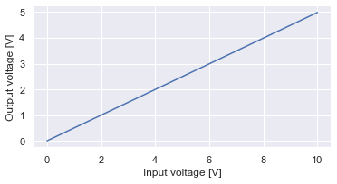

```python
import numpy as np
import matplotlib.pyplot as plt
import pandas as pd
import seaborn as sns
sns.set()

df = pd.read_csv("example/example1.csv")
sns.relplot(
    data=df,
    x="Input voltage [V]",
    y="Output voltage [V]",
    kind="line", palette="tab10", height=3, aspect=16/9,
)
plt.show()
```

## Example 2: Signal generator and spectrum analyzer

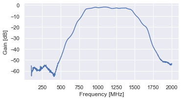

```python
import numpy as np
import matplotlib.pyplot as plt
import pandas as pd
import seaborn as sns
sns.set()

df = pd.read_csv("example/example2.csv")
df["Frequency [MHz]"] = df["Frequency [Hz]"]*1e-6
sns.relplot(
    data=df,
    x="Frequency [MHz]",
    y="Gain [dB]",
    kind="line", palette="tab10", height=3, aspect=16/9,
)
plt.show()
```

## Exercise 1: Harmonics (1)

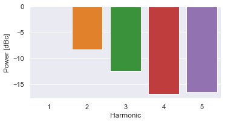

```python
import numpy as np
import matplotlib.pyplot as plt
import pandas as pd
import seaborn as sns
sns.set()

df = pd.read_csv("example/exercise1.csv")
df["Power [dBc]"] = df["Power [dBm]"] - max(df["Power [dBm]"])
sns.catplot(
    data=df,
    x="Harmonic",
    y="Power [dBc]",
    kind="bar", palette="tab10", height=3, aspect=16/9,
)
plt.show()
```

## Exercise 2: Harmonics (2)

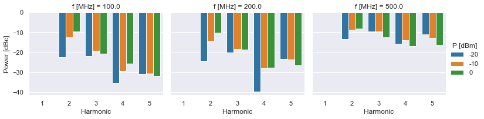

```python
import numpy as np
import matplotlib.pyplot as plt
import pandas as pd
import seaborn as sns
sns.set()

df = pd.read_csv("example/exercise2.csv")
df["P [dBm]"] = df["Generator power [dBm]"]
df["f [MHz]"] = df["Generator frequency [Hz]"]/1e6

def append_dBc(df):
    df["Power [dBc]"] = df["Power [dBm]"] - max(df["Power [dBm]"])
    return df

df = df.groupby(["f [MHz]", "P [dBm]"]).apply(append_dBc).reset_index(drop=True)
sns.catplot(
    data=df,
    x="Harmonic", y="Power [dBc]",
    hue="P [dBm]", col="f [MHz]",
    kind="bar", palette="tab10", height=3, aspect=1.2,
)
plt.show()
```